# Tidy Meta Profiles using Bioconductor and the Tidyverse

Malte Thodberg

2 January 2019

#### Abstract

The TeMPO R/Bioconductor package provides fast and easy to use functions for generating *meta profiles* (also known as *meta genes*, *average profiles* or *average footprints*) over one or more sets of genomic locations and signals. TeMPO uses highly efficient, but difficult to use Bioconductor S4-classes to calculcate summaries, but outputs results as ordinary data.frames or tibbles for easy and flexible plotting with the popular ggplot2 package. TeMPO thereby provides the glue for working with Bioconductor-objects in the tidyverse. Additional meta-profile functionalites such as stranded meta-profiles, outlier-trimming and alternative summary functions are available for advanced users.

#### Package

TeMPO 0.99.5

# 1 Installation

Install the most recent stable version from Bioconductor:

```r
if (!requireNamespace("BiocManager", quietly=TRUE))
    install.packages("BiocManager")
BiocManager::install("TeMPO")
```

And load `TeMPO`:

```r
library(TeMPO)
```

Alternatively, you can install the development version directly from GitHub using `devtools`:

```r
devtools::install_github("MalteThodberg/TeMPO")
```

# 2 Getting help and contact

For general questions about the usage of TeMPO, use the [official Bioconductor support forum](https://support.bioconductor.org) and tag your question “TeMPO”. We strive to answer questions as quickly as possible.

For technical questions, bug reports and suggestions for new features, we refer to the [TeMPO github page](https://github.com/MalteThodberg/TeMPO/issues)

# 3 Usage examples

## 3.1 Inputs and outputs

TeMPO can calculate the summarized signal (e.g. the average counts-per-millon) across a set of genomic regions (e.g. Transcription Start Sites (TSSs) and enhancers). TeMPO needs the following input:

- One or more sets of genomic sites as a GRanges or GRangesList.
- One or more sets of genome-wide signals as a BigWigFile or BigWigFilelist (or RleList or RleListList if the genome is very small and/or the genome-wide signal is very sparse).

TeMPO will output the result in “tidy” format as a tibble, making it easy to further analyze or plot the data using *ggplot2* and the *tidyverse* packages.

## 3.2 Example data sets

TeMPO example below use example data for hela cells (hg19) chromosomes 20-22 from the following sources:

- CAGE data from “Nuclear stability and transcriptional directionality separate functionally distinct RNA species” by Andersson *et al* preprocessed using the *CAGEfightR* package.
- ChIP-Seq and DNase-Seq data from The Roadmap Epigenomics Project (obtained via the *AnnotationHub* package with IDs: AH32877, AH32879, AH32881, AH32884).

First, we load the needed packages:

```r
library(AnnotationHub)
library(tidyverse)

# Use light ggplot2 theme
theme_set(theme_light())
```

`CAGE_clusters` contain the location of TSSs and enhancer found using the CAGEfightR package. TSSs and enhancers are expected to show different epigenetic modifications, reflecting their different function:

```r
data("CAGE_clusters")
CAGE_clusters
```

```
## GRanges object with 595 ranges and 3 metadata columns:
##                             seqnames    ranges strand |            score
##                                <Rle> <IRanges>  <Rle> |        <numeric>
##         chr20:340666-341149    chr20    340907      * |      0.252943123
##         chr20:358957-359469    chr20    359213      * |      0.257864759
##         chr20:903843-904434    chr20    904138      * |      0.152325408
##       chr20:2983446-2984019    chr20   2983732      * |      0.101550272
##       chr20:3061580-3062161    chr20   3061783      * |      0.190937752
##                         ...      ...       ...    ... .              ...
##   chr22:42475675-42475789;+    chr22  42475705      + | 68.8727955169163
##   chr22:43547512-43547631;+    chr22  43547580      + | 375.664515486352
##   chr22:44319612-44319697;+    chr22  44319686      + |  86.229792749384
##   chr22:44351262-44351453;+    chr22  44351323      + | 111.069414689469
##   chr22:44420133-44420250;+    chr22  44420183      + | 130.960061421145
##                             clusterType     txType
##                             <character>   <factor>
##         chr20:340666-341149    enhancer intergenic
##         chr20:358957-359469    enhancer intergenic
##         chr20:903843-904434    enhancer intergenic
##       chr20:2983446-2984019    enhancer     intron
##       chr20:3061580-3062161    enhancer intergenic
##                         ...         ...        ...
##   chr22:42475675-42475789;+         TSS   promoter
##   chr22:43547512-43547631;+         TSS   promoter
##   chr22:44319612-44319697;+         TSS   promoter
##   chr22:44351262-44351453;+         TSS   promoter
##   chr22:44420133-44420250;+         TSS   promoter
##   -------
##   seqinfo: 93 sequences (1 circular) from hg19 genome
```

`CAGE_plus` and `CAGE_minus` contains the pooled CAGE signal across wildtype cells (WT) and exosome knock-out cell (KD). The exosome knock-down is expected to stabilize eRNA transcripts produced from enhancers that are normally quickly degraded. As the CAGE data is very sparse, it can be loaded directly into memory as an `RleListList`:

```r
data("CAGE_plus")
data("CAGE_minus")
CAGE_plus
```

```
## RleListList of length 2
## names(2): WT KD
```

We can obtain epigenetic data for comparison to the CAGE data using the The Roadmap Epigenomics Project via the *AnnotationHub* package. As ChIP-Seq and DNase-signal is not sparse, we will store these signals as BigWigFile-objects rather than load them into memory:

**NOTE:** *The first time you run this, it will take several minutes for AnnotationHub to download the file. After that, AnnotationHub will simply fetch the file from cache, as is done here.*

```r
# Setup AnnotationHub
ah <- AnnotationHub()

# Retrive data and save as BigWigFileList
ChIP_Seq <- list(DNase="AH32877",
     H3K4me1="AH32879",
     H3K4me3="AH32881",
     H3K27ac="AH32884") %>%
    lapply(function(x) ah[[x]]) %>%
    as("List")
```

Below are examples of generating metaprofiles for different combinations of input.

## 3.3 Single set of sites & single genome-wide signal

A simple example of (unstranded) DNAse-signal around promoters:

```r
promoters_only <- subset(CAGE_clusters, txType == "promoter")

SS1 <- tidyMetaProfile(sites = promoters_only,
                      forward=ChIP_Seq$DNase, reverse=NULL,
                      upstream=300, downstream=300)

head(SS1)
```

```
## # A tibble: 6 x 3
##    pos1  pos0 sense
##   <int> <int> <dbl>
## 1  -300  -300  10.4
## 2  -299  -299  10.4
## 3  -298  -298  10.5
## 4  -297  -297  10.5
## 5  -296  -296  10.5
## 6  -295  -295  10.6
```

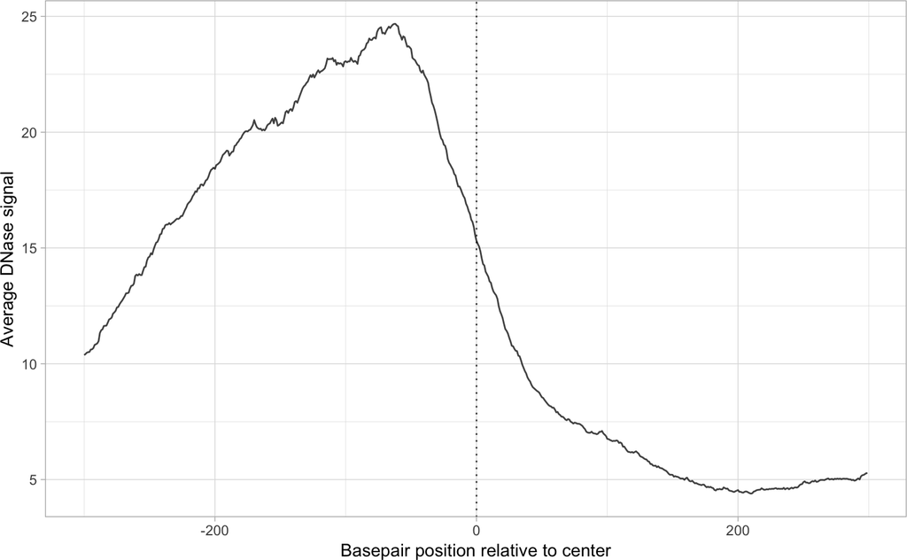

```r
ggplot(SS1, aes(x=pos0, y=sense)) +
    geom_line(alpha=0.75) +
    geom_vline(xintercept=0, alpha=0.75, linetype="dotted") +
    labs(x="Basepair position relative to center",
         y="Average DNase signal")
```

Classic example of bidirectional transcription of eRNAs at enhancers shown using a stranded meta-profile:

```r
enhancers_only <- subset(CAGE_clusters, clusterType == "enhancer")

SS2 <- tidyMetaProfile(sites = enhancers_only,
                      forward=CAGE_plus$WT, reverse=CAGE_minus$WT,
                      upstream=250, downstream=250)

head(SS2)
```

```
## # A tibble: 6 x 4
##    pos1  pos0    sense     anti
##   <int> <int>    <dbl>    <dbl>
## 1  -250  -250 0.000371 0.00104
## 2  -249  -249 0        0.000871
## 3  -248  -248 0        0.000905
## 4  -247  -247 0.000426 0.000837
## 5  -246  -246 0.000239 0.000250
## 6  -245  -245 0.000108 0.00122
```

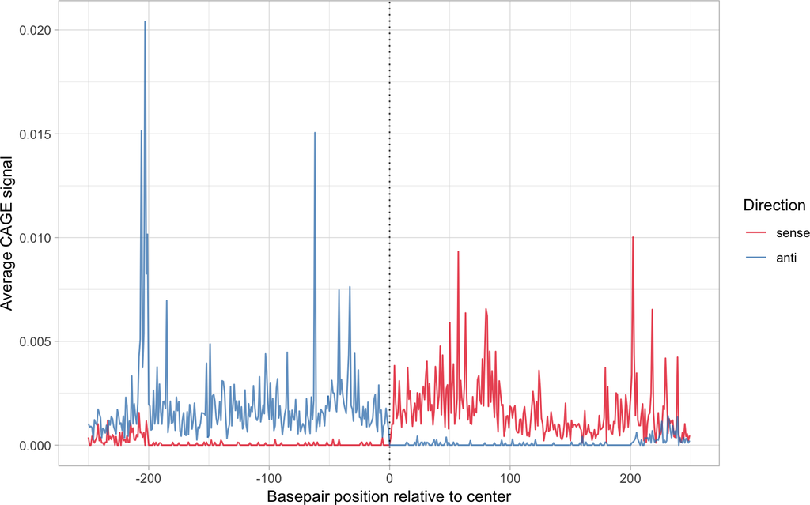

```r
SS2 %>%
    gather(key="direction", value="score", sense, anti, factor_key=TRUE) %>%
    ggplot(aes(x=pos0, y=score, color=direction)) +
    scale_color_brewer("Direction", palette="Set1") +
    geom_line(alpha=0.75) +
    geom_vline(xintercept=0, alpha=0.75, linetype="dotted") +
    labs(x="Basepair position relative to center",
         y="Average CAGE signal")
```

## 3.4 Single set of sites & multiple genome-wide signal

Multiple different epigentic signals across a single set of sites:

```r
SM <- tidyMetaProfile(sites = promoters_only,
                      forward=ChIP_Seq, reverse=NULL,
                      upstream=300, downstream=300)

head(SM)
```

```
## # A tibble: 6 x 4
##   signal  pos1  pos0 sense
##   <chr>  <int> <int> <dbl>
## 1 DNase   -300  -300  10.4
## 2 DNase   -299  -299  10.4
## 3 DNase   -298  -298  10.5
## 4 DNase   -297  -297  10.5
## 5 DNase   -296  -296  10.5
## 6 DNase   -295  -295  10.6
```

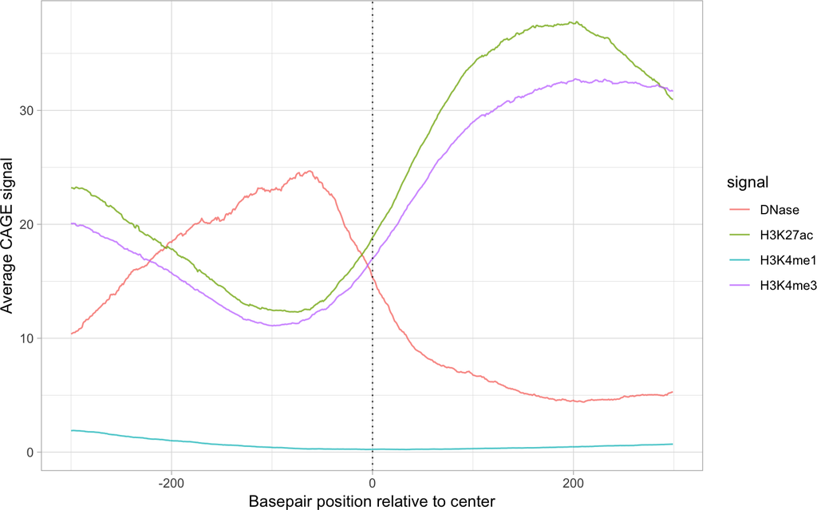

```r
ggplot(SM, aes(x=pos0, y=sense, color=signal)) +
    geom_line(alpha=0.75) +
    geom_vline(xintercept=0, alpha=0.75, linetype="dotted") +
    labs(x="Basepair position relative to center",
         y="Average CAGE signal")
```

## 3.5 Multiple sets of sites & single genome-wide signal

```r
by_txType <- CAGE_clusters %>%
    subset(clusterType == "TSS" & txType %in% c("promoter",
                                                "fiveUTR",
                                                "proximal")) %>%
    splitAsList(.$txType, drop=TRUE)

MS <- tidyMetaProfile(sites = by_txType,
                      forward=ChIP_Seq$DNase, reverse=NULL,
                      upstream=300, downstream=300)

head(MS)
```

```
## # A tibble: 6 x 4
##   sites     pos1  pos0 sense
##   <chr>    <int> <int> <dbl>
## 1 promoter  -300  -300  10.4
## 2 promoter  -299  -299  10.4
## 3 promoter  -298  -298  10.5
## 4 promoter  -297  -297  10.5
## 5 promoter  -296  -296  10.5
## 6 promoter  -295  -295  10.6
```

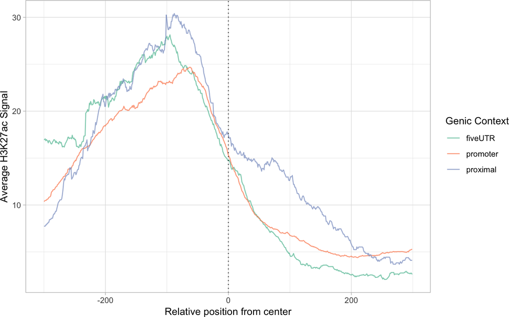

```r
ggplot(MS, aes(x=pos0, y=sense, color=sites)) +
    geom_line(alpha=0.75) +
    geom_vline(xintercept = 0, linetype="dotted", alpha=0.75) +
    scale_color_brewer("Genic Context", palette="Set2") +
    labs(x="Relative position from center",
         y="Average H3K27ac Signal")
```

## 3.6 Multiple sets of sites & multiple genome-wide signal

Meta-profile showing the difference in epigentic modifications at TSSs vs enhancers:

```r
by_clusterType <- split(CAGE_clusters, CAGE_clusters$clusterType)

MM1 <- tidyMetaProfile(sites = by_clusterType,
                      forward=ChIP_Seq, reverse=NULL,
                      upstream=300, downstream=300)

head(MM1)
```

```
## # A tibble: 6 x 5
##   signal sites  pos1  pos0 sense
##   <chr>  <chr> <int> <int> <dbl>
## 1 DNase  TSS    -300  -300  11.5
## 2 DNase  TSS    -299  -299  11.6
## 3 DNase  TSS    -298  -298  11.6
## 4 DNase  TSS    -297  -297  11.6
## 5 DNase  TSS    -296  -296  11.6
## 6 DNase  TSS    -295  -295  11.7
```

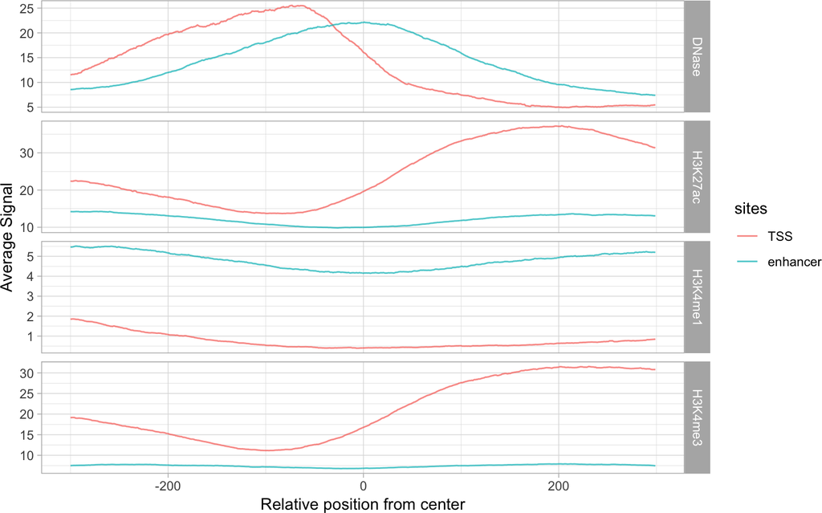

```r
ggplot(MM1, aes(x=pos0, y=sense, color=sites)) +
    geom_line(alpha=0.75) +
    facet_grid(signal~., scales="free_y") +
    labs(x="Relative position from center",
         y="Average Signal")
```

Meta-profile showing the effect of the exosome knockdown on eRNAs detected by CAGE:

```r
MM2 <- tidyMetaProfile(sites = by_clusterType,
                      forward=CAGE_plus, reverse=CAGE_minus,
                      upstream=300, downstream=300)

head(MM2)
```

```
## # A tibble: 6 x 6
##   signal sites  pos1  pos0    sense  anti
##   <chr>  <chr> <int> <int>    <dbl> <dbl>
## 1 WT     TSS    -300  -300 0            0
## 2 WT     TSS    -299  -299 0.000500     0
## 3 WT     TSS    -298  -298 0.00241      0
## 4 WT     TSS    -297  -297 0.00255      0
## 5 WT     TSS    -296  -296 0            0
## 6 WT     TSS    -295  -295 0            0
```

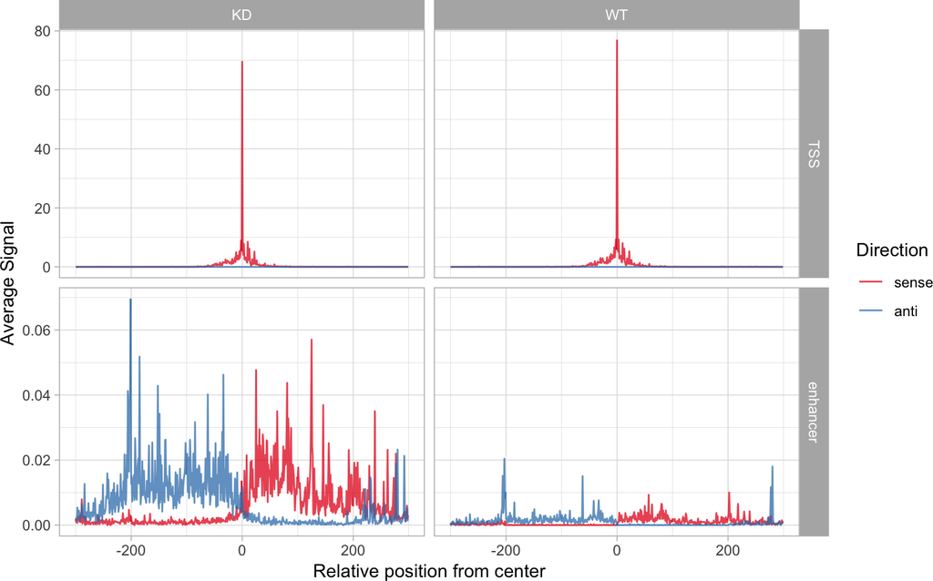

```r
MM2 %>%
    gather(key="direction", value="score", sense, anti, factor_key=TRUE) %>%
    ggplot(aes(x=pos0, y=score, color=direction)) +
    geom_line(alpha=0.75) +
    facet_grid(sites~signal, scales="free_y") +
    scale_color_brewer("Direction", palette="Set1") +
    labs(x="Relative position from center",
         y="Average Signal")
```

# 4 Advanced usage

## 4.1 Parallel Execution

In case multiple genomic signals are provided (Multiple `BigWigFile`-objects in a `BigWigFileList` or multiple `RleList`-objects in an `RleListList`), signals can be analyzed in parallel using the *BiocParallel* package. TidyMetaProfile uses the default registered backend:

```r
library(BiocParallel)

# Set the backend to run calculations in series
register(SerialParam())

# Set the backend to run parallelize calculations using i.e. 3 cores:
register(MulticoreParam(workers=3))
```

## 4.2 Alternative meta-summary functions

Instead of calculating the mean across sites, alternative summary functions can be provide. For example, instead of the average meta-profile, we can plot the median meta-profile:

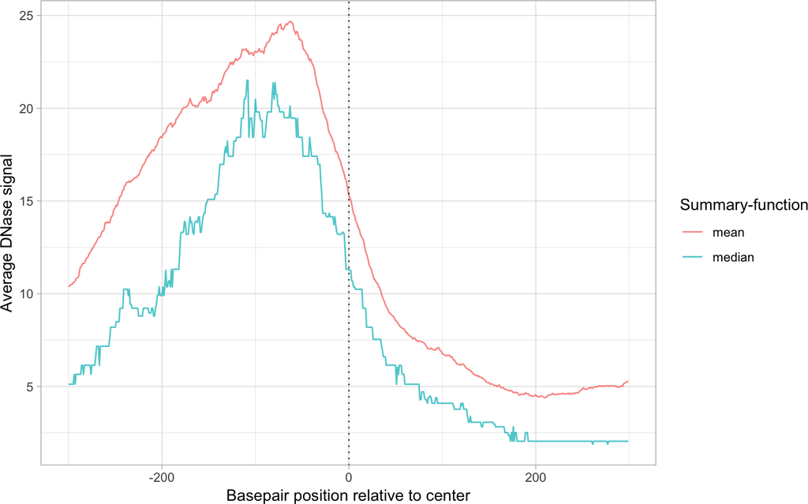

```r
# Recalculate the first example using medians
SS1_median <- tidyMetaProfile(sites = promoters_only,
                      forward=ChIP_Seq$DNase, reverse=NULL,
                      upstream=300, downstream=300,
                      sumFun = matrixStats::colMedians)

# Merge the two profiles and plot
list(mean=SS1, median=SS1_median) %>%
    bind_rows(.id="summary") %>%
    ggplot(aes(x=pos0, y=sense, color=summary)) +
    geom_line(alpha=0.75) +
    geom_vline(xintercept=0, alpha=0.75, linetype="dotted") +
    scale_color_discrete("Summary-function") +
    labs(x="Basepair position relative to center",
         y="Average DNase signal")
```

## 4.3 Outlier removal/trimming

In many cases, a few sites may have very extreme values which can disproportionally skew the calculated average profiles. tidyMetaProfile can automatically trim the sites with lowest and/or highest signals based on quantiles:

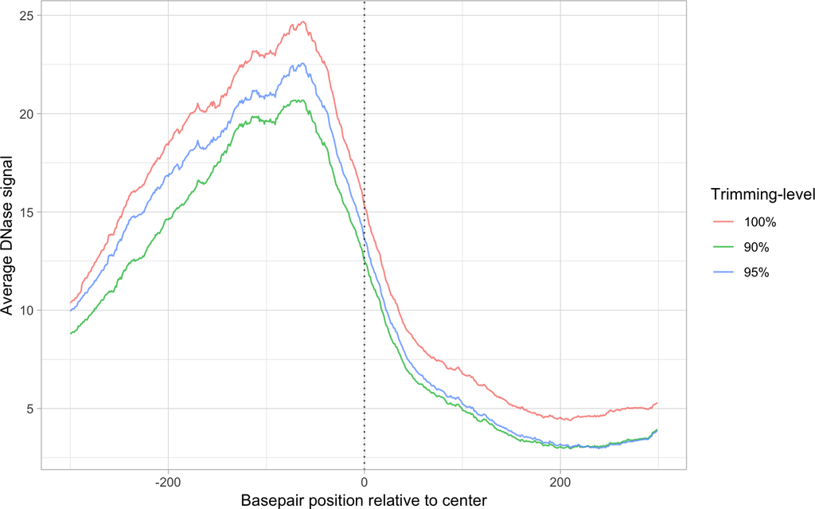

```r
# Recalculate the first example with different quantile trimmings:
SS1_95percent <- tidyMetaProfile(sites = promoters_only,
                      forward=ChIP_Seq$DNase, reverse=NULL,
                      upstream=300, downstream=300,
                      trimUpper=0.95)

SS1_90percent <- tidyMetaProfile(sites = promoters_only,
                      forward=ChIP_Seq$DNase, reverse=NULL,
                      upstream=300, downstream=300,
                      trimUpper=0.90)

# Merge the three profiles and plot
list(`100%`=SS1,
     `95%`=SS1_95percent,
     `90%`=SS1_90percent) %>%
    bind_rows(.id="summary") %>%
    ggplot(aes(x=pos0, y=sense, color=summary)) +
    geom_line(alpha=0.75) +
    geom_vline(xintercept=0, alpha=0.75, linetype="dotted") +
    scale_color_discrete("Trimming-level") +
    labs(x="Basepair position relative to center",
         y="Average DNase signal")
```

## 4.4 Access to low-level functions

The low-level functions used by tidyMetaProfile are all exposed for advanced user:

- `agnosticImport`: Import of chunks from BigWigFile or RleList
- `wideMetaProfile`: Output results as a site-by-position matrix.
- `quantileTrim`: Trim outliers from a single matrix or a pair of matrices.

The man pages for those functions contains details on how to use them.